# Peer Assessment II

## 2.2 Part 2 - Development and assessment of an initial model, following a semi-guided process of analysis

### 2.2.1 Section 2.1 An Initial Model

In building a model, it is often useful to start by creating a simple, intuitive initial model based on the results of the exploratory data analysis. (Note: The goal at this stage is **not** to identify the “best” possible model but rather to choose a reasonable and understandable starting point. Later you will expand and revise this model to create your final model.

Based on your EDA, select *at most* 10 predictor variables from “ames_train” and create a linear model for `price` (or a transformed version of price) using those variables. Provide the *R code* and the *summary output table* for your model, a *brief justification* for the variables you have chosen, and a *brief discussion* of the model results in context (focused on the variables that appear to be important predictors and how they relate to sales price).

My first model uses three variables – `Overall.Qual`, `Lot.Area`, and `area`. I log transform the price and area variables to take into account outliers and the non-linear nature of the two variables which I discovered during the EDA stage.

```r
lm1 <- with(ames_train, lm(log(price) ~ log(area) + Overall.Qual + Lot.Area))
summary(lm1)
```

```
##
## Call:
## lm(formula = log(price) ~ log(area) + Overall.Qual + Lot.Area)
##
## Residuals:
##      Min       1Q   Median       3Q      Max
## -1.60509 -0.09464  0.01470  0.11794  0.62765
##
## Coefficients:
##               Estimate Std. Error t value Pr(>|t|)
## (Intercept)  7.955e+00  1.618e-01  49.165  < 2e-16 ***
## log(area)    4.015e-01  2.540e-02  15.806  < 2e-16 ***
## Overall.Qual 1.822e-01  5.905e-03  30.862  < 2e-16 ***
## Lot.Area     4.443e-06  6.733e-07   6.598 6.75e-11 ***
## ---
## Signif. codes:  0 '***' 0.001 '**' 0.01 '*' 0.05 '.' 0.1 ' ' 1
##
## Residual standard error: 0.2019 on 996 degrees of freedom
## Multiple R-squared:  0.7702, Adjusted R-squared:  0.7695
## F-statistic:  1113 on 3 and 996 DF,  p-value: < 2.2e-16
```

### 2.2.2 Section 2.2 Model Selection

Now either using `BAS` another stepwise selection procedure choose the “best” model you can, using your initial model as your starting point. Try at least two different model selection methods and compare their results. Do they both arrive at the same model or do they disagree? What do you think this means?

AIC and BIC cirteria were used in model selection. Using both directions I came up with the same solution each time.

```r
lm1.aic <- MASS::stepAIC(lm1, direction = c("both"), k = 2)
```

```
## Start:  AIC=-3195.53
## log(price) ~ log(area) + Overall.Qual + Lot.Area
##
##                Df Sum of Sq    RSS     AIC
## <none>                      40.618 -3195.5
## - Lot.Area      1     1.776 42.394 -3154.7
## - log(area)     1    10.189 50.807 -2973.7
## - Overall.Qual  1    38.843 79.461 -2526.5
```

```r
summary(lm1.aic)
```

```
##
## Call:
## lm(formula = log(price) ~ log(area) + Overall.Qual + Lot.Area)
##
## Residuals:
##      Min       1Q   Median       3Q      Max
## -1.60509 -0.09464  0.01470  0.11794  0.62765
##
## Coefficients:
##               Estimate Std. Error t value Pr(>|t|)
## (Intercept)  7.955e+00  1.618e-01  49.165  < 2e-16 ***
## log(area)    4.015e-01  2.540e-02  15.806  < 2e-16 ***
## Overall.Qual 1.822e-01  5.905e-03  30.862  < 2e-16 ***
## Lot.Area     4.443e-06  6.733e-07   6.598 6.75e-11 ***
## ---
## Signif. codes:  0 '***' 0.001 '**' 0.01 '*' 0.05 '.' 0.1 ' ' 1
##
## Residual standard error: 0.2019 on 996 degrees of freedom
## Multiple R-squared:  0.7702, Adjusted R-squared:  0.7695
## F-statistic:  1113 on 3 and 996 DF,  p-value: < 2.2e-16
```

```r
lm1.bic <- MASS::stepAIC(lm1, direction = c("both"), k = log(1000))
```

```
## Start:  AIC=-3175.9
## log(price) ~ log(area) + Overall.Qual + Lot.Area
##
##                Df Sum of Sq    RSS     AIC
## <none>                      40.618 -3175.9
## - Lot.Area      1     1.776 42.394 -3140.0
## - log(area)     1    10.189 50.807 -2959.0
## - Overall.Qual  1    38.843 79.461 -2511.8
```

```r
summary(lm1.bic)
```

```
##
## Call:
## lm(formula = log(price) ~ log(area) + Overall.Qual + Lot.Area)
##
## Residuals:
##      Min       1Q   Median       3Q      Max
## -1.60509 -0.09464  0.01470  0.11794  0.62765
##
## Coefficients:
##               Estimate Std. Error t value Pr(>|t|)
## (Intercept)  7.955e+00  1.618e-01  49.165  < 2e-16 ***
## log(area)    4.015e-01  2.540e-02  15.806  < 2e-16 ***
## Overall.Qual 1.822e-01  5.905e-03  30.862  < 2e-16 ***
## Lot.Area     4.443e-06  6.733e-07   6.598 6.75e-11 ***
## ---
## Signif. codes:  0 '***' 0.001 '**' 0.01 '*' 0.05 '.' 0.1 ' ' 1
##
## Residual standard error: 0.2019 on 996 degrees of freedom
## Multiple R-squared:  0.7702, Adjusted R-squared:  0.7695
## F-statistic:  1113 on 3 and 996 DF,  p-value: < 2.2e-16
```

### 2.2.3 Section 2.3 Initial Model Residuals

One way to assess the performance of a model is to examine the model’s residuals. In the space below, create a residual plot for your preferred model from above and use it to assess whether your model appears to fit the data well. Comment on any interesting structure in the residual plot (trend, outliers, etc.) and briefly discuss potential implications it may have for your model and inference / prediction you might produce.

The residuals are not evenly distributed over price ranges, and at lower and higher ranges the prices are poorly forcast.

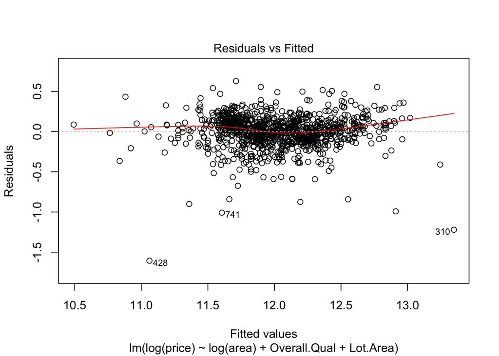

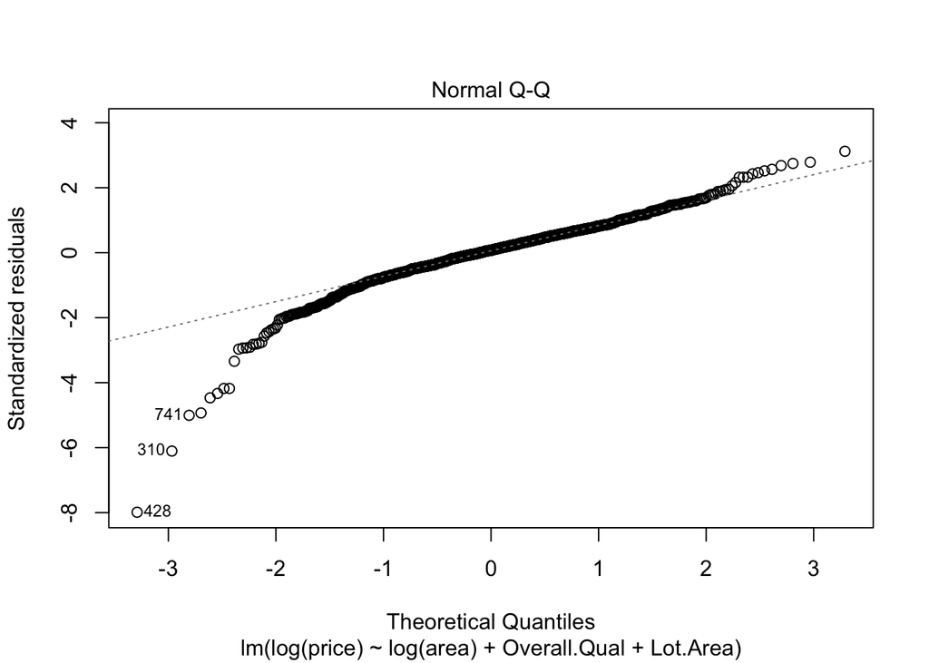

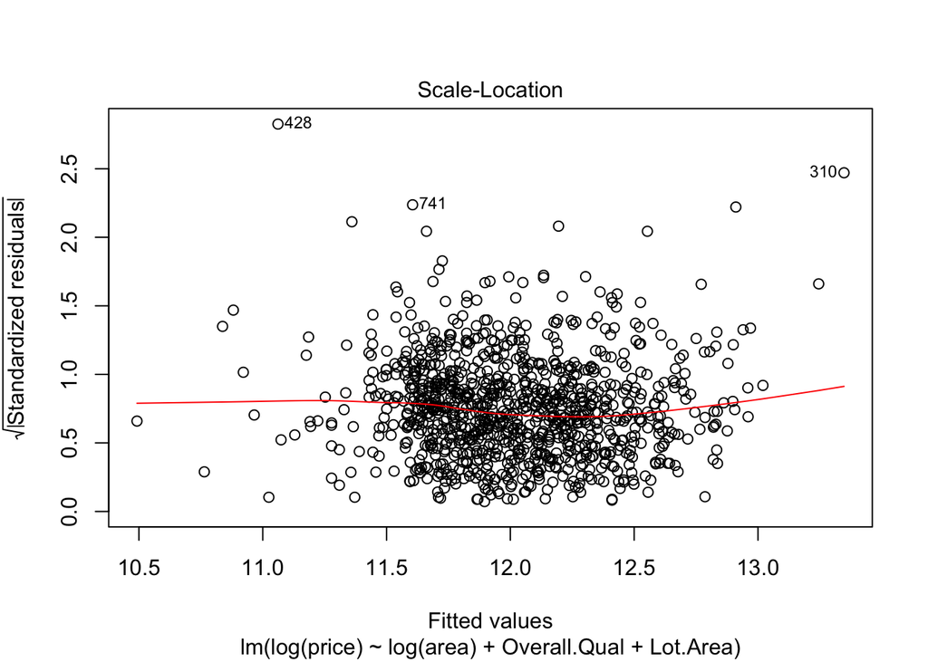

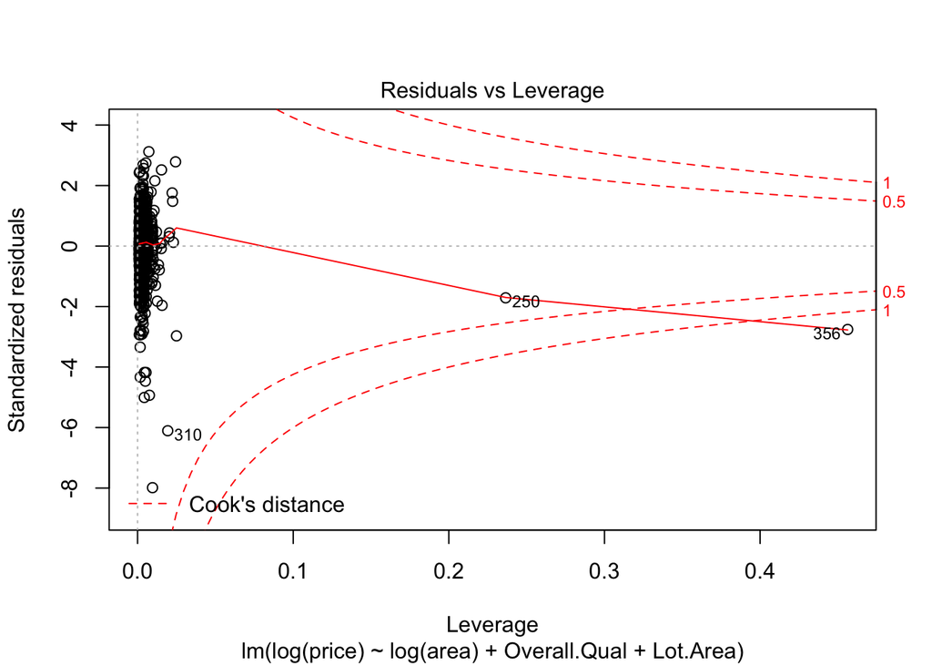

```r
plot(lm1.bic)
```

### 2.2.4 Section 2.4 Initial Model RMSE

You can calculate it directly based on the model output. Be specific about the units of your RMSE (depending on whether you transformed your response variable). The value you report will be more meaningful if it is in the original units (dollars).

```r
pred <- exp(predict(lm1.bic, ames_train))
resid <- with(ames_train, price - pred)
rmse <- sqrt(mean(resid^2))
pander(c(RMSE = rmse))
```

| RMSE |
| --- |
| 39689 |

### 2.2.5 Section 2.5 Overfitting

The process of building a model generally involves starting with an initial model (as you have done above), identifying its shortcomings, and adapting the model accordingly. This process may be repeated several times until the model fits the data reasonably well. However, the model may do well on training data but perform poorly out-of-sample (meaning, on a dataset other than the original training data) because the model is overly-tuned to specifically fit the training data. This is called “overfitting.” To determine whether overfitting is occurring on a model, compare the performance of a model on both in-sample and out-of-sample data sets. To look at performance of your initial model on out-of-sample data, you will use the data set `ames_test`.

```r
load("ames_test.Rdata")
```

Use your model from above to generate predictions for the housing prices in the test data set. Are the predictions significantly more accurate (compared to the actual sales prices) for the training data than the test data? Why or why not? Briefly explain how you determined that (what steps or processes did you use)?

The RMSE is quite close and slightly lower than the training data. The predicion of housing price for the test data is appropriately fitting.

```r
pred.test <- exp(predict(lm1.bic, ames_test))
resid.test <- with(ames_test, price - pred.test)
rmse.test <- sqrt(mean(resid.test^2))
pander(c(RMSE.test = rmse.test))
```

| RMSE.test |
| --- |
| 36918 |

**Note to the learner:** If in real-life practice this out-of-sample analysis shows evidence that the training data fits your model a lot better than the test data, it is probably a good idea to go back and revise the model (usually by simplifying the model) to reduce this overfitting. For simplicity, we do not ask you to do this on the assignment, however.

## 2.3 Part 3 Development of a Final Model

Now that you have developed an initial model to use as a baseline, create a final model with *at most* 20 variables to predict housing prices in Ames, IA, selecting from the full array of variables in the dataset and using any of the tools that we introduced in this specialization.

Carefully document the process that you used to come up with your final model, so that you can answer the questions below.

### 2.3.1 Section 3.1 Final Model

Provide the summary table for your model.

The final model starts with the 16 significant variables. The R Squared value is 0.88, 0.11 higher than the previous simple model.

```r
lm2 <- with(ames_train, lm(log(price) ~ log(area) + Overall.Qual + log(Lot.Area) + Bedroom.AbvGr + Garage.Cars + Total.Bsmt.SF + BsmtFin.SF.1 + Full.Bath + Half.Bath + Year.Built + Lot.Area + Garage.Cars + X1st.Flr.SF + X2nd.Flr.SF + Central.Air + Overall.Cond + Land.Slope + Neighborhood))
lm2.bic <- MASS::stepAIC(lm2, k = log(1000), trace = F)
summary(lm2.bic)
```

```
##
## Call:
## lm(formula = log(price) ~ log(area) + Overall.Qual + log(Lot.Area) +
##     Bedroom.AbvGr + Garage.Cars + Total.Bsmt.SF + BsmtFin.SF.1 +
##     Year.Built + Central.Air + Overall.Cond)
##
## Residuals:
##      Min       1Q   Median       3Q      Max
## -1.46785 -0.06308  0.00394  0.07274  0.49465
##
## Coefficients:
##                 Estimate Std. Error t value Pr(>|t|)
## (Intercept)   -4.646e-01  5.252e-01  -0.885    0.377
## log(area)      4.580e-01  2.477e-02  18.492  < 2e-16 ***
## Overall.Qual   9.188e-02  5.662e-03  16.227  < 2e-16 ***
## log(Lot.Area)  1.014e-01  1.007e-02  10.070  < 2e-16 ***
## Bedroom.AbvGr -3.772e-02  7.359e-03  -5.125 3.58e-07 ***
## Garage.Cars    3.422e-02  8.599e-03   3.979 7.41e-05 ***
## Total.Bsmt.SF  1.034e-04  1.578e-05   6.554 8.99e-11 ***
## BsmtFin.SF.1   9.235e-05  1.233e-05   7.491 1.52e-13 ***
## Year.Built     3.616e-03  2.370e-04  15.253  < 2e-16 ***
## Central.AirY   9.235e-02  2.278e-02   4.054 5.42e-05 ***
## Overall.Cond   6.463e-02  4.907e-03  13.172  < 2e-16 ***
## ---
## Signif. codes:  0 '***' 0.001 '**' 0.01 '*' 0.05 '.' 0.1 ' ' 1
##
## Residual standard error: 0.1435 on 987 degrees of freedom
##   (2 observations deleted due to missingness)
## Multiple R-squared:  0.8846, Adjusted R-squared:  0.8834
## F-statistic: 756.4 on 10 and 987 DF,  p-value: < 2.2e-16
```

### 2.3.2 Section 3.2 Transformation

Did you decide to transform any variables? Why or why not? Explain in a few sentences.

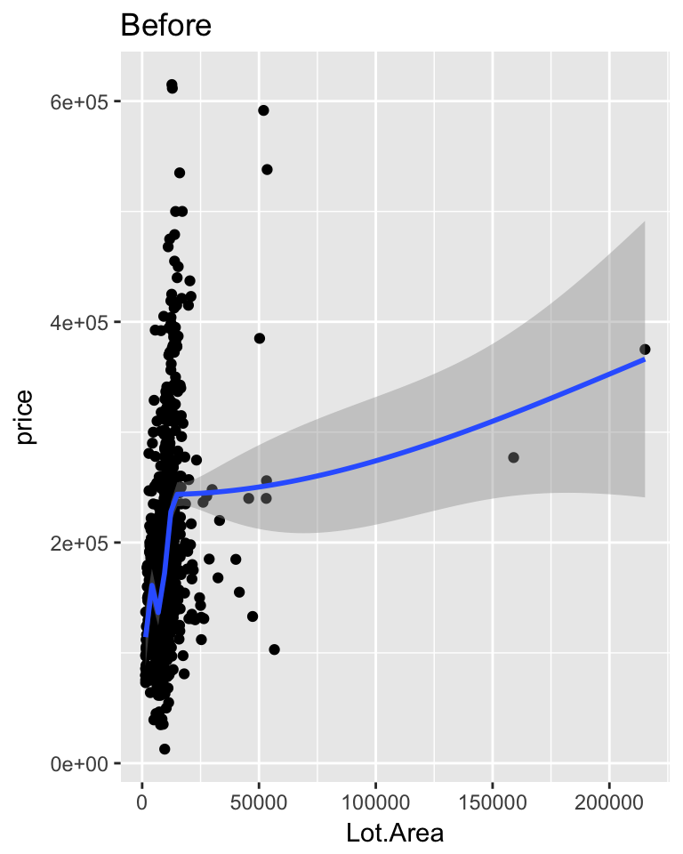

```r
ames_train %>% ggplot(aes(y=price, x = Lot.Area )) + geom_point() + stat_smooth() + ggtitle("Before")
```

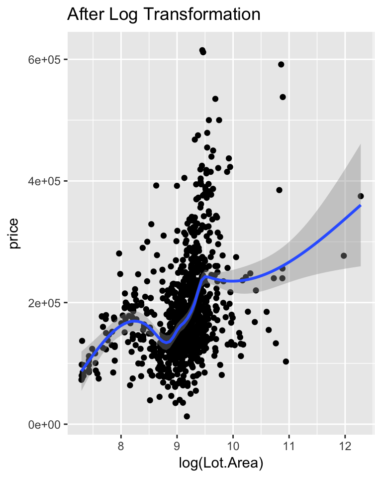

```r
ames_train %>% ggplot(aes(y=price, x = log(Lot.Area) )) + geom_point() + stat_smooth() + ggtitle("After Log Transformation")
```

### 2.3.3 Section 3.3 Variable Interaction

Did you decide to include any variable interactions? Why or why not? Explain in a few sentences.

I didn’t include variable interations because most of the data is related to one another. The number of bedrooms affects square footage, garage size, and more. Thus, I would need to heavily integrate interactions and I’m not sure if the incremental gains would be worthwhile. For example, the R Squared value below is 0.01 better with two simple interactions from the `lm1` model.

```r
lm.interactions <- with(ames_train, lm(log(price) ~ area + area*Bedroom.AbvGr + area*Lot.Area + Overall.Qual))
summary(lm.interactions)
```

```
##
## Call:
## lm(formula = log(price) ~ area + area * Bedroom.AbvGr + area *
##     Lot.Area + Overall.Qual)
##
## Residuals:
##      Min       1Q   Median       3Q      Max
## -1.66572 -0.08920  0.01372  0.11541  0.89792
##
## Coefficients:
##                      Estimate Std. Error t value Pr(>|t|)
## (Intercept)         1.016e+01  6.192e-02 164.150   <2e-16 ***
## area                5.610e-04  4.712e-05  11.906   <2e-16 ***
## Bedroom.AbvGr       5.079e-03  2.207e-02   0.230   0.8181
## Lot.Area            3.050e-05  3.079e-06   9.905   <2e-16 ***
## Overall.Qual        1.743e-01  6.118e-03  28.492   <2e-16 ***
## area:Bedroom.AbvGr -3.399e-05  1.304e-05  -2.606   0.0093 **
## area:Lot.Area      -1.315e-08  1.505e-09  -8.739   <2e-16 ***
## ---
## Signif. codes:  0 '***' 0.001 '**' 0.01 '*' 0.05 '.' 0.1 ' ' 1
##
## Residual standard error: 0.194 on 993 degrees of freedom
## Multiple R-squared:  0.7885, Adjusted R-squared:  0.7872
## F-statistic: 616.9 on 6 and 993 DF,  p-value: < 2.2e-16
```

### 2.3.4 Section 3.4 Variable Selection

What method did you use to select the variables you included? Why did you select the method you used? Explain in a few sentences.

EDA and BIC stepwise model selection using the `stepAIC` function in the `MASS` package. I whittled down the variable count this way.

```r
lm2 <- with(ames_train, lm(log(price) ~ log(area) + Overall.Qual + log(Lot.Area) + Bedroom.AbvGr + Garage.Cars + Total.Bsmt.SF + BsmtFin.SF.1 + Full.Bath + Half.Bath + Year.Built + Lot.Area + Garage.Cars + X1st.Flr.SF + X2nd.Flr.SF + Central.Air + Overall.Cond + Land.Slope + Neighborhood))
lm2.bic <- MASS::stepAIC(lm2, k = log(1000), trace = F)
summary(lm2.bic)
```

```
##
## Call:
## lm(formula = log(price) ~ log(area) + Overall.Qual + log(Lot.Area) +
##     Bedroom.AbvGr + Garage.Cars + Total.Bsmt.SF + BsmtFin.SF.1 +
##     Year.Built + Central.Air + Overall.Cond)
##
## Residuals:
##      Min       1Q   Median       3Q      Max
## -1.46785 -0.06308  0.00394  0.07274  0.49465
##
## Coefficients:
##                 Estimate Std. Error t value Pr(>|t|)
## (Intercept)   -4.646e-01  5.252e-01  -0.885    0.377
## log(area)      4.580e-01  2.477e-02  18.492  < 2e-16 ***
## Overall.Qual   9.188e-02  5.662e-03  16.227  < 2e-16 ***
## log(Lot.Area)  1.014e-01  1.007e-02  10.070  < 2e-16 ***
## Bedroom.AbvGr -3.772e-02  7.359e-03  -5.125 3.58e-07 ***
## Garage.Cars    3.422e-02  8.599e-03   3.979 7.41e-05 ***
## Total.Bsmt.SF  1.034e-04  1.578e-05   6.554 8.99e-11 ***
## BsmtFin.SF.1   9.235e-05  1.233e-05   7.491 1.52e-13 ***
## Year.Built     3.616e-03  2.370e-04  15.253  < 2e-16 ***
## Central.AirY   9.235e-02  2.278e-02   4.054 5.42e-05 ***
## Overall.Cond   6.463e-02  4.907e-03  13.172  < 2e-16 ***
## ---
## Signif. codes:  0 '***' 0.001 '**' 0.01 '*' 0.05 '.' 0.1 ' ' 1
##
## Residual standard error: 0.1435 on 987 degrees of freedom
##   (2 observations deleted due to missingness)
## Multiple R-squared:  0.8846, Adjusted R-squared:  0.8834
## F-statistic: 756.4 on 10 and 987 DF,  p-value: < 2.2e-16
```

### 2.3.5 Section 3.5 Model Testing

How did testing the model on out-of-sample data affect whether or how you changed your model? Explain in a few sentences.

```r
pred.train <- exp(predict(lm1.bic, ames_train))
resid.train <- with(ames_train, price - pred.train)
rmse.train <- sqrt(mean(resid.train^2))
pred.test <- exp(predict(lm2.bic, ames_test))
resid.test <- with(ames_test, price - pred.test)
rmse.test <- sqrt(mean(resid.test^2))
pander(c(RMSE.train = rmse.train, RMSE.test = rmse.test))
```

| RMSE.train | RMSE.test |
| --- | --- |
| 39689 | 42967 |

## 2.4 Part 4 Final Model Assessment

### 2.4.1 Section 4.1 Final Model Residual

For your final model, create and briefly interpret an informative plot of the residuals.

The final model used 10 significant variables to predict housing prices. Based on the residuations, we have only a handful out outlier points, 998, and 310, for example. Those two data points were outliers because of novel characteristics in the way they were documented in the data set. The residuals are distributed with a skew toward the $100,000 to $200,000 range, with a normal distribution, meaning, it is easier to forecast the price of a middle-class house than an expensive house. This mirrors reality – the rich don’t know how much they should be paying for a big house and often times overpay, which is why everyone tries building big houses (to get more margin).

```r
summary(lm2.bic)
```

```
##
## Call:
## lm(formula = log(price) ~ log(area) + Overall.Qual + log(Lot.Area) +
##     Bedroom.AbvGr + Garage.Cars + Total.Bsmt.SF + BsmtFin.SF.1 +
##     Year.Built + Central.Air + Overall.Cond)
##
## Residuals:
##      Min       1Q   Median       3Q      Max
## -1.46785 -0.06308  0.00394  0.07274  0.49465
##
## Coefficients:
##                 Estimate Std. Error t value Pr(>|t|)
## (Intercept)   -4.646e-01  5.252e-01  -0.885    0.377
## log(area)      4.580e-01  2.477e-02  18.492  < 2e-16 ***
## Overall.Qual   9.188e-02  5.662e-03  16.227  < 2e-16 ***
## log(Lot.Area)  1.014e-01  1.007e-02  10.070  < 2e-16 ***
## Bedroom.AbvGr -3.772e-02  7.359e-03  -5.125 3.58e-07 ***
## Garage.Cars    3.422e-02  8.599e-03   3.979 7.41e-05 ***
## Total.Bsmt.SF  1.034e-04  1.578e-05   6.554 8.99e-11 ***
## BsmtFin.SF.1   9.235e-05  1.233e-05   7.491 1.52e-13 ***
## Year.Built     3.616e-03  2.370e-04  15.253  < 2e-16 ***
## Central.AirY   9.235e-02  2.278e-02   4.054 5.42e-05 ***
## Overall.Cond   6.463e-02  4.907e-03  13.172  < 2e-16 ***
## ---
## Signif. codes:  0 '***' 0.001 '**' 0.01 '*' 0.05 '.' 0.1 ' ' 1
##
## Residual standard error: 0.1435 on 987 degrees of freedom
##   (2 observations deleted due to missingness)
## Multiple R-squared:  0.8846, Adjusted R-squared:  0.8834
## F-statistic: 756.4 on 10 and 987 DF,  p-value: < 2.2e-16
```

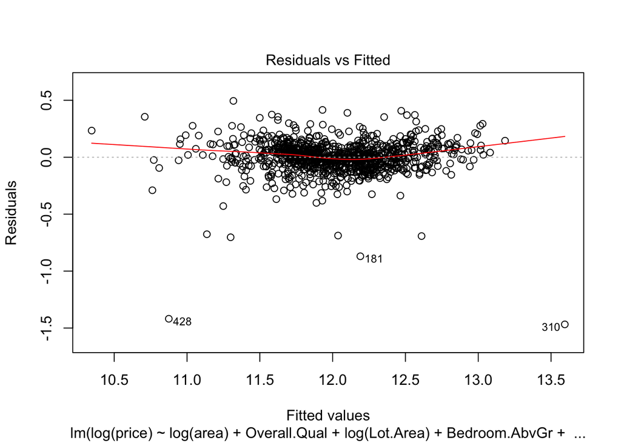

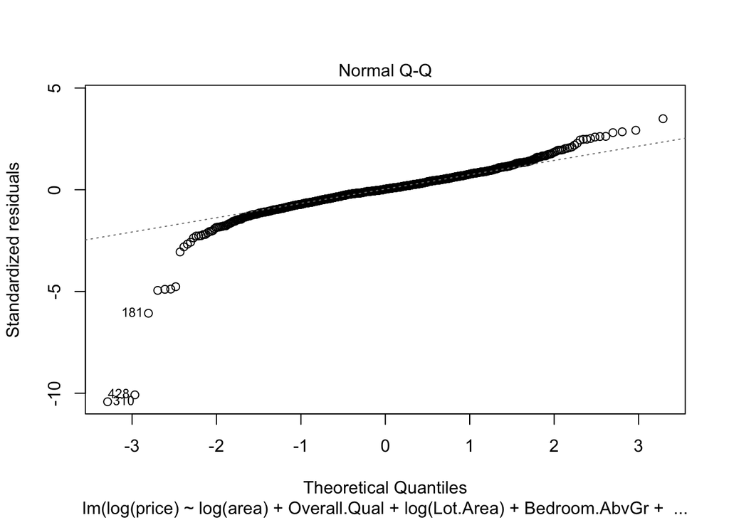

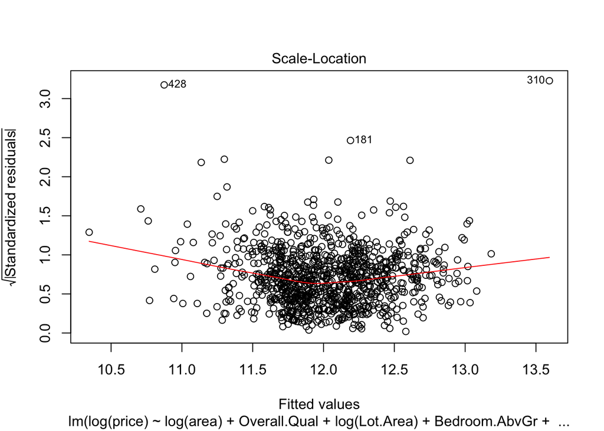

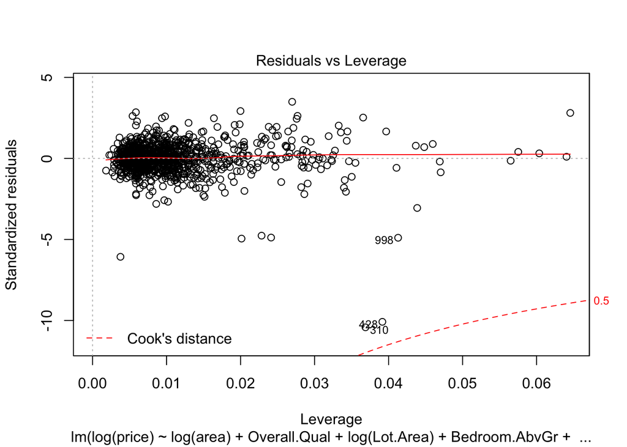

```r
plot(lm2.bic)
```

### 2.4.2 Section 4.2 Final Model RMSE

For your final model, calculate and briefly comment on the RMSE.

```r
pred.lm1 <- exp(predict(lm2.bic, ames_test))
resid.lm1 <- with(ames_test, price - pred.test)
rmse.lm1 <- sqrt(mean(resid.lm1^2))
pander(c(RMSE.lm1 = rmse.lm1, RMSE.train = rmse.train, RMSE.test = rmse.test))
```

| RMSE.lm1 | RMSE.train | RMSE.test |
| --- | --- | --- |
| 42967 | 39689 | 42967 |

### 2.4.3 Section 4.3 Final Model Evaluation

What are some strengths and weaknesses of your model?

The model is simple, which is good. It doesn’t take into account interactions, which is bad. That, and it also doesn’t modify all the appropriate variables.

### 2.4.4 Section 4.4 Final Model Validation

Testing your final model on a separate, validation data set is a great way to determine how your model will perform in real-life practice.

You will use the “ames_validation” dataset to do some additional assessment of your final model. Discuss your findings, be sure to mention: * What is the RMSE of your final model when applied to the validation data?  
* How does this value compare to that of the training data and/or testing data? * What percentage of the 95% predictive confidence (or credible) intervals contain the true price of the house in the validation data set?  
* From this result, does your final model properly reflect uncertainty?

```r
load("ames_validation.Rdata")
```

```r
pred.final <- exp(predict(lm2.bic, ames_validation))
resid.final <- with(ames_validation, price - pred.final)
rmse.final <- sqrt(mean(resid.final^2))
pander(c(RMSE.lm1 = rmse.lm1, RMSE.train = rmse.train, RMSE.test = rmse.test, RMSE.final = rmse.final))
```

| RMSE.lm1 | RMSE.train | RMSE.test | RMSE.final |
| --- | --- | --- | --- |
| 42967 | 39689 | 42967 | 52887 |

```r
pred.validate <- exp(predict(lm2.bic, ames_validation, interval = "predict", level = 0.95))
coverage <- mean(ames_validation$price > pred.validate[,"lwr"] & ames_validation$price < pred.validate[,"upr"])
pander(c(RMSE.lm1 = rmse.lm1, RMSE.train = rmse.train, RMSE.test = rmse.test, RMSE.final = rmse.final, coverage = coverage))
```

| RMSE.lm1 | RMSE.train | RMSE.test | RMSE.final | coverage |
| --- | --- | --- | --- | --- |
| 42967 | 39689 | 42967 | 52887 | 0.966 |

The model doesn’t perform that bad and there is about 97% coverage.